# LowbirthweightProject

Christina Duggins

11/29/2020

#The data set from package “MASS” in R. The name of this data set is “birthwt”. #The data were collected at Baystate Medical Center, Springfield, MA in 1986.

#There are 189 observations and 10 varibles as in details:

#low: indicator of birth weight less than 2500 grams (2.5 kg)

#age: mother’s age in years

#lwt: mother’s weight in pounds at last menstrual period

#race: mother’s race (1= white, 2= black, 3= other)

#smoke: mother’s smoking status during pregnancy

#pt1: number of previous premature labors

#ht: history of hypertension

#ui: presence of uterine irrtability

#ftv: number of doctor visits during the 1st trimester.

#bwt: birthweight in grams

#I’m interested in finding out what are the factors that affect the infant birthweight. I will explore the data by using graphs and multiple regression to find out which factors impact the birth weight.

#The codes are:

```r
#install.packages("ISLR")
#install.packages("MASS")
#install.packages("gridExtra")
library(tidyverse)
library(dplyr)
library(MASS)
birthwt = read.csv(file.choose(), header=T)
```

```r
birthwt$low<- factor(birthwt$low,levels = c("0", "1") , labels = c("No", "Yes"))
table(birthwt$low)
```

```
##
##  No Yes
## 130  59
```

```r
birthwt$race <- factor(birthwt$race,levels = c("1", "2","3") , labels = c("white", "black","other"))
table(birthwt$race)
```

```
##
## white black other
##    96    26    67
```

```r
birthwt$ht <- factor(birthwt$ht,levels = c("0", "1") , labels = c("No", "Yes" ))
table(birthwt$ht)
```

```
##
##  No Yes
## 177  12
```

```r
birthwt$ui <- factor(birthwt$ui,levels = c("0", "1") , labels = c("No", "Yes" ))
table(birthwt$ui)
```

```
##
##  No Yes
## 161  28
```

```r
birthwt$ptl <- factor(birthwt$ptl,levels = c("0", "1") , labels = c("No", "Yes" ))
table(birthwt$ptl)
```

```
##
##  No Yes
## 159  24
```

```r
head(birthwt)
```

```
##    X low age lwt  race smoke ptl ht  ui ftv  bwt
## 1 85  No  19 182 black     0  No No Yes   0 2523
## 2 86  No  33 155 other     0  No No  No   3 2551
## 3 87  No  20 105 white     1  No No  No   1 2557
## 4 88  No  21 108 white     1  No No Yes   2 2594
## 5 89  No  18 107 white     1  No No Yes   0 2600
## 6 91  No  21 124 other     0  No No  No   0 2622
```

```r
names(birthwt)
```

```
##  [1] "X"     "low"   "age"   "lwt"   "race"  "smoke" "ptl"   "ht"    "ui"
## [10] "ftv"   "bwt"
```

```r
dim(birthwt)
```

```
## [1] 189  11
```

```r
?birthwt
```

```
## starting httpd help server ... done
```

#1: Age vs. birthweight, whether there is a correlation relationship of the mother’s age in years with the birth weight in grams. As we know, mother’s age after 35 tend to have larger babies, whereas, teenage pregnancies produce more underweight baby.

```r
cor(birthwt$age,birthwt$bwt)
```

```
## [1] 0.09031781
```

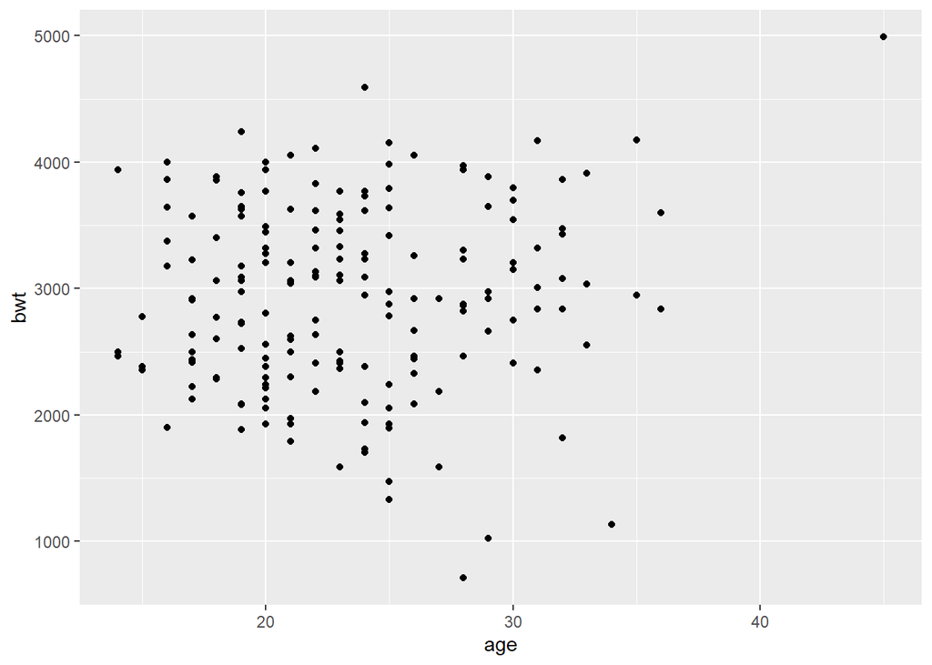

```r
ggplot(data=birthwt, aes(x = age, y = bwt) ) + geom_point()
```

```r
model_age<-lm(bwt~age, data=birthwt)
summary(model_age)
```

```
##
## Call:
## lm(formula = bwt ~ age, data = birthwt)
##
## Residuals:
##      Min       1Q   Median       3Q      Max
## -2294.78  -517.63    10.51   530.80  1774.92
##
## Coefficients:
##             Estimate Std. Error t value Pr(>|t|)
## (Intercept)  2655.74     238.86   11.12   <2e-16 ***
## age            12.43      10.02    1.24    0.216
## ---
## Signif. codes:  0 '***' 0.001 '**' 0.01 '*' 0.05 '.' 0.1 ' ' 1
##
## Residual standard error: 728.2 on 187 degrees of freedom
## Multiple R-squared:  0.008157,   Adjusted R-squared:  0.002853
## F-statistic: 1.538 on 1 and 187 DF,  p-value: 0.2165
```

```r
lm(formula = bwt~age, data= birthwt)
```

```
##
## Call:
## lm(formula = bwt ~ age, data = birthwt)
##
## Coefficients:
## (Intercept)          age
##     2655.74        12.43
```

#Based on the results above, the p-value of t-test shows that the regression coefficient of variable age (mother’s age in years) is statistically not signficant at the level of significant 5%. That indicates the variable age does not impact on the birthweight.

#2 Mother’s weight in lbs since the last menstrual cycle. A BMI less than 19 is likely to have a low weight baby, and a BMI more than 24 at at risk for larger babies.

```r
cor(birthwt$lwt,birthwt$bwt)
```

```
## [1] 0.1857333
```

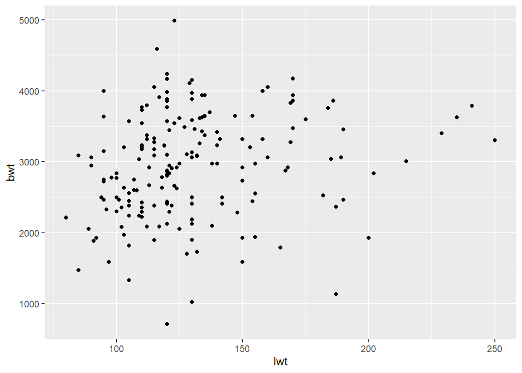

```r
ggplot(data = birthwt,  mapping= aes(x = lwt, y = bwt)) + geom_point()
```

#The figure indicates that mother’s weight prior to pregnancy has a slightly positive linear relationship with baby’s birthweight.

```r
model_lwt<-lm(bwt~lwt, data=birthwt)
summary(model_lwt)
```

```
##
## Call:
## lm(formula = bwt ~ lwt, data = birthwt)
##
## Residuals:
##      Min       1Q   Median       3Q      Max
## -2192.12  -497.97    -3.84   508.32  2075.60
##
## Coefficients:
##             Estimate Std. Error t value Pr(>|t|)
## (Intercept) 2369.624    228.493  10.371   <2e-16 ***
## lwt            4.429      1.713   2.585   0.0105 *
## ---
## Signif. codes:  0 '***' 0.001 '**' 0.01 '*' 0.05 '.' 0.1 ' ' 1
##
## Residual standard error: 718.4 on 187 degrees of freedom
## Multiple R-squared:  0.0345, Adjusted R-squared:  0.02933
## F-statistic: 6.681 on 1 and 187 DF,  p-value: 0.0105
```

```r
lm(formula = bwt~lwt, data= birthwt)
```

```
##
## Call:
## lm(formula = bwt ~ lwt, data = birthwt)
##
## Coefficients:
## (Intercept)          lwt
##    2369.624        4.429
```

#Based on the results above, despite the p-value of t-test shows that the regression coefficient of variable lwt (mother’s weight in pounds at last menstrual period) is signficantly different from 0 at the level of significant 5%, but adjusted R-squared shows that only 2.9% variability in birthweight is explained by lwt. It seems that this varible lwt has a slightly impact on the birthweight.

#3 Baby with birthweight less than 2.5 kg indicator #similarly, whethere there is an impact of low on birthweight.

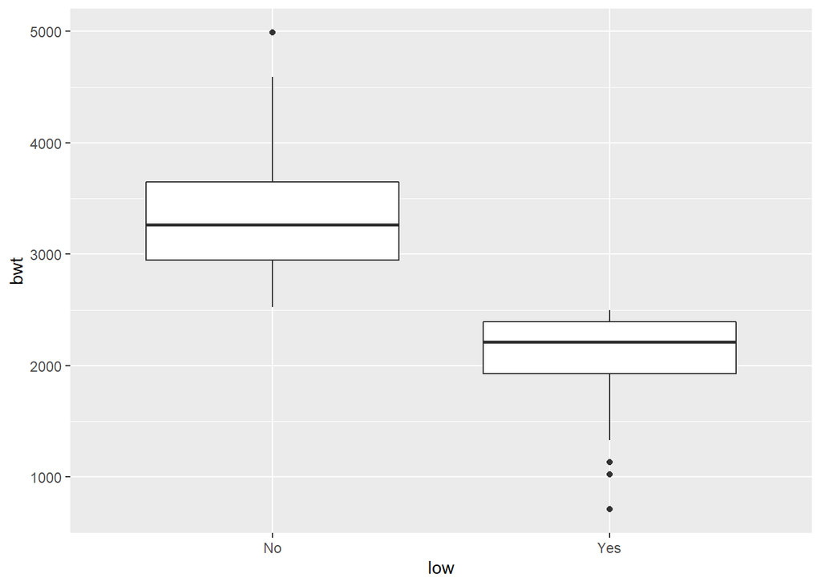

```r
ggplot(data = birthwt,  mapping= aes(x = low, y = bwt)) + geom_boxplot()
```

##This figure shows that the varible low (birthwt < 2500 grams) impacts to the bwt (in grams)

#4 Race vs. birthweight

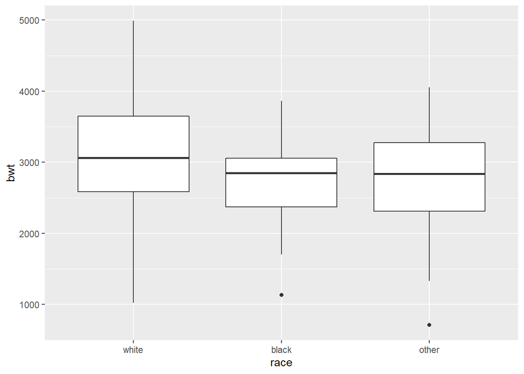

```r
ggplot(data = birthwt,  mapping= aes(x = race, y = bwt)) + geom_boxplot()
```

#birthweight slightly depends on the race. This figure indicates the white race has more children that are weighted more than 2500 grams.

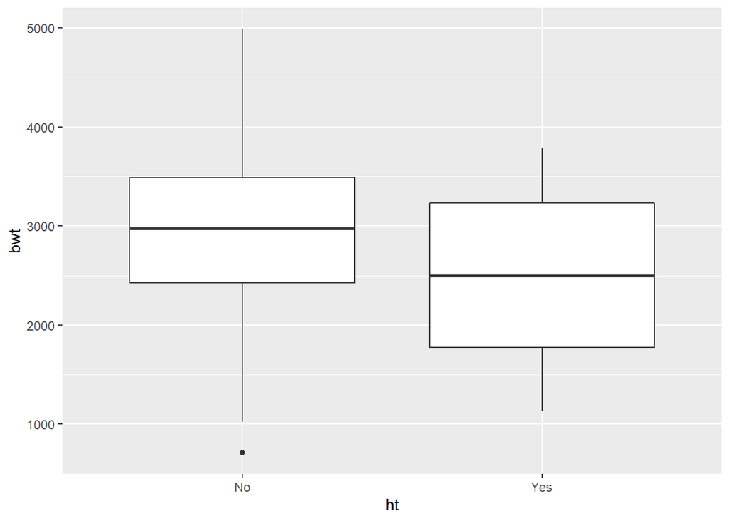

```r
ggplot(data = birthwt,  mapping= aes(x = ht, y = bwt)) + geom_boxplot()
```

#6 Uterine Irritatbility vs. birthweight

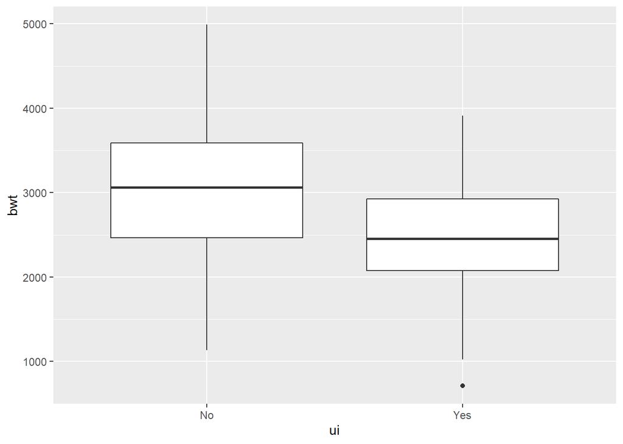

```r
ggplot(data = birthwt,  mapping= aes(x = ui, y = bwt)) + geom_boxplot()
```

#Uterine Irritability does have an impact on low birthweight, sometimes the birthweight can be less than 1000 grams.

#7: Previous premature labors impact on birthweight

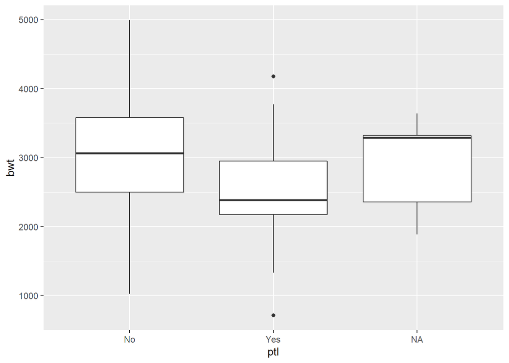

```r
ggplot(data = birthwt,  mapping= aes(x = ptl, y = bwt)) + geom_boxplot()
```

```r
model<-lm(bwt~., data=birthwt)
summary(model)
```

```
##
## Call:
## lm(formula = bwt ~ ., data = birthwt)
##
## Residuals:
##     Min      1Q  Median      3Q     Max
## -850.17  -56.27    8.39   59.08  816.69
##
## Coefficients:
##              Estimate Std. Error t value Pr(>|t|)
## (Intercept) 1646.9667    84.1495  19.572   <2e-16 ***
## X             11.5728     0.2972  38.934   <2e-16 ***
## lowYes        62.1216    39.0505   1.591    0.114
## age           -0.3386     2.1080  -0.161    0.873
## lwt           -0.6163     0.3843  -1.604    0.111
## raceblack     -4.3293    33.4331  -0.129    0.897
## raceother    -42.2543    25.8990  -1.632    0.105
## smoke        -13.8502    24.0600  -0.576    0.566
## ptlYes        -8.2082    33.1090  -0.248    0.804
## htYes       -107.0798    44.4448  -2.409    0.017 *
## uiYes        -48.4570    32.1623  -1.507    0.134
## ftv            1.9266    10.0385   0.192    0.848
## ---
## Signif. codes:  0 '***' 0.001 '**' 0.01 '*' 0.05 '.' 0.1 ' ' 1
##
## Residual standard error: 139.7 on 171 degrees of freedom
##   (6 observations deleted due to missingness)
## Multiple R-squared:  0.9657, Adjusted R-squared:  0.9634
## F-statistic: 437.1 on 11 and 171 DF,  p-value: < 2.2e-16
```

```r
lm(formula = bwt~., data= birthwt)
```

```
##
## Call:
## lm(formula = bwt ~ ., data = birthwt)
##
## Coefficients:
## (Intercept)            X       lowYes          age          lwt    raceblack
##   1646.9667      11.5728      62.1216      -0.3386      -0.6163      -4.3293
##   raceother        smoke       ptlYes        htYes        uiYes          ftv
##    -42.2543     -13.8502      -8.2082    -107.0798     -48.4570       1.9266
```

```r
model_updated<-lm(bwt~.-low-age-lwt-race-smoke-ptl-ui-ftv, data=birthwt)
summary(model_updated)
```

```
##
## Call:
## lm(formula = bwt ~ . - low - age - lwt - race - smoke - ptl -
##     ui - ftv, data = birthwt)
##
## Residuals:
##     Min      1Q  Median      3Q     Max
## -921.17  -51.46    2.98   51.90  852.81
##
## Coefficients:
##              Estimate Std. Error t value Pr(>|t|)
## (Intercept) 1584.9942    23.0218  68.848   <2e-16 ***
## X             11.2929     0.1656  68.204   <2e-16 ***
## htYes       -108.7522    42.1620  -2.579   0.0107 *
## ---
## Signif. codes:  0 '***' 0.001 '**' 0.01 '*' 0.05 '.' 0.1 ' ' 1
##
## Residual standard error: 140.3 on 180 degrees of freedom
##   (6 observations deleted due to missingness)
## Multiple R-squared:  0.9636, Adjusted R-squared:  0.9632
## F-statistic:  2380 on 2 and 180 DF,  p-value: < 2.2e-16
```

```r
lm(formula = bwt~., data= birthwt)
```

```
##
## Call:
## lm(formula = bwt ~ ., data = birthwt)
##
## Coefficients:
## (Intercept)            X       lowYes          age          lwt    raceblack
##   1646.9667      11.5728      62.1216      -0.3386      -0.6163      -4.3293
##   raceother        smoke       ptlYes        htYes        uiYes          ftv
##    -42.2543     -13.8502      -8.2082    -107.0798     -48.4570       1.9266
```